# R Notebook

```r
#nejake kniznice
library(dplyr)
library(tidyverse)
library(data.table)
library(corrplot)
library(RColorBrewer)
library(rcompanion)
library(lawstat)
```

## Dáta

### Tabuľka game

Tabuľka obsahuje základné dáta jednotlivých zápasov. Neobsahuje však detailné informácie o tímoch alebo tímových štatistikách konkrétneho zápasu. Dokážeme však pomocou atribútov game_id, away_team_id a home_team_id namapovať iné tabuľky tak, aby sme dostali jeden dataset so všetkými hodnotami.

```r
#setwd(dir)
path <- ('data/game.csv')
game <- fread(path)
head(game)
```

| game_id | season | type | date_time_GMT | away_team_id | home_team_id | away_goals | home_goals | outcome | home_rink_side_start | venue | venue_link | venue_time_zone_id | venue_time_zone_offset | venue_time_zone_tz |
| --- | --- | --- | --- | --- | --- | --- | --- | --- | --- | --- | --- | --- | --- | --- |
| 2016020045 | 20162017 | R | 2016-10-19 00:30:00 | 4 | 16 | 4 | 7 | home win REG | right | United Center | /api/v1/venues/null | America/Chicago | -5 | CDT |
| 2017020812 | 20172018 | R | 2018-02-07 00:00:00 | 24 | 7 | 4 | 3 | away win OT | left | KeyBank Center | /api/v1/venues/null | America/New_York | -4 | EDT |
| 2015020314 | 20152016 | R | 2015-11-24 01:00:00 | 21 | 52 | 4 | 1 | away win REG | right | MTS Centre | /api/v1/venues/null | America/Winnipeg | -5 | CDT |
| 2015020849 | 20152016 | R | 2016-02-17 00:00:00 | 52 | 12 | 1 | 2 | home win REG | right | PNC Arena | /api/v1/venues/null | America/New_York | -4 | EDT |
| 2017020586 | 20172018 | R | 2017-12-30 03:00:00 | 20 | 24 | 1 | 2 | home win REG | left | Honda Center | /api/v1/venues/null | America/Los_Angeles | -7 | PDT |
| 2016020610 | 20162017 | R | 2017-01-10 00:30:00 | 15 | 8 | 4 | 1 | away win REG | right | Centre Bell | /api/v1/venues/null | America/Montreal | -4 | EDT |

Niektoré atribúty sú z pohľadu štatistiky nezaujímavé a teda ich môžeme odstrániť pred spájaním tabuliek. Napríklad údaje o časovej zóne, alebo identifikátory štadiónov a pod.

```r
game <- subset(game, select=-c(venue_link,venue_time_zone_id, venue_time_zone_offset, venue_time_zone_tz))
head(game)
```

| game_id | season | type | date_time_GMT | away_team_id | home_team_id | away_goals | home_goals | outcome | home_rink_side_start | venue |
| --- | --- | --- | --- | --- | --- | --- | --- | --- | --- | --- |
| 2016020045 | 20162017 | R | 2016-10-19 00:30:00 | 4 | 16 | 4 | 7 | home win REG | right | United Center |
| 2017020812 | 20172018 | R | 2018-02-07 00:00:00 | 24 | 7 | 4 | 3 | away win OT | left | KeyBank Center |
| 2015020314 | 20152016 | R | 2015-11-24 01:00:00 | 21 | 52 | 4 | 1 | away win REG | right | MTS Centre |
| 2015020849 | 20152016 | R | 2016-02-17 00:00:00 | 52 | 12 | 1 | 2 | home win REG | right | PNC Arena |
| 2017020586 | 20172018 | R | 2017-12-30 03:00:00 | 20 | 24 | 1 | 2 | home win REG | left | Honda Center |
| 2016020610 | 20162017 | R | 2017-01-10 00:30:00 | 15 | 8 | 4 | 1 | away win REG | right | Centre Bell |

```r
dim(game)
```

```
[1] 26305    11
```

Prvotnou analýzou sme zistili, že v minulej sezóne sa odohralo približne 2500 zápasov, z čoho bolo +-10 percent v playoff. S týmto počtom zápasov nám stačí pracovať s poslednou sezónou pri trénovaní stroja.

```r
dim(game[game$season==20192020,])
```

```
[1] 2425   11
```

```r
dim(subset(game, season==20192020 & type=='P'))
```

```
[1] 231  11
```

```r
#game <- game[!(outcome %like% "tbc")]
```

Počet hier v minulej sezóne bol omnoho vyšší ako je zvykom, tak sme skontrolovali existenciu duplikátnych záznamov v tabuľke. Z výpisu nižšie sme odhalili 2570 duplikátov v celej tabuľke.

```r
game[duplicated(game)]
```

| game_id | season | type | date_time_GMT | away_team_id | home_team_id | away_goals | home_goals | outcome | home_rink_side_start | venue |
| --- | --- | --- | --- | --- | --- | --- | --- | --- | --- | --- |
| 2019020001 | 20192020 | R | 2019-10-02 23:00:00 | 9 | 10 | 3 | 5 | home win REG | right | Scotiabank Arena |
| 2019020002 | 20192020 | R | 2019-10-03 00:00:00 | 15 | 19 | 3 | 2 | away win OT | left | Enterprise Center |
| 2019020003 | 20192020 | R | 2019-10-03 02:00:00 | 23 | 22 | 2 | 3 | home win REG | left | Rogers Place |
| 2019020004 | 20192020 | R | 2019-10-03 02:30:00 | 28 | 54 | 1 | 4 | home win REG | NA | T-Mobile Arena |
| 2019020005 | 20192020 | R | 2019-10-03 23:00:00 | 13 | 14 | 2 | 5 | home win REG | left | Amalie Arena |
| 2019020006 | 20192020 | R | 2019-10-03 23:00:00 | 52 | 3 | 4 | 6 | home win REG | right | Madison Square Garden |
| 2019020007 | 20192020 | R | 2019-10-03 23:00:00 | 7 | 5 | 3 | 1 | away win REG | left | PPG Paints Arena |
| 2019020008 | 20192020 | R | 2019-10-03 23:00:00 | 8 | 12 | 3 | 4 | home win OT | right | PNC Arena |
| 2019020009 | 20192020 | R | 2019-10-04 00:00:00 | 30 | 18 | 2 | 5 | home win REG | left | Bridgestone Arena |
| 2019020010 | 20192020 | R | 2019-10-04 00:30:00 | 6 | 25 | 2 | 1 | away win REG | right | American Airlines Center |

[output cut: 990 more lines]

Aby sme si overili existenciu duplikátov, tak sme si vypísali náhodnú hru z vyššie vygenerovanej tabuľky duplikátov.

```r
game[game$game_id==2019020369]
```

| game_id | season | type | date_time_GMT | away_team_id | home_team_id | away_goals | home_goals | outcome | home_rink_side_start | venue |
| --- | --- | --- | --- | --- | --- | --- | --- | --- | --- | --- |
| 2019020369 | 20192020 | R | 2019-11-26 | 9 | 29 | 0 | 1 | home win REG | left | Nationwide Arena |
| 2019020369 | 20192020 | R | 2019-11-26 | 9 | 29 | 0 | 1 | home win REG | left | Nationwide Arena |

Duplikáty sme eliminovali využitím funkcie distinct, ktorá zachová jedinečné záznamy. Elimináciu duplikátov sme overili opäť použitím funkcie duplicated, ktorá vrátila 0 záznamov. Počet záznamov v tabuľke klesol o 2570, aktuálny počet záznamov je teda 23735.

```r
game <- distinct(game)
game[duplicated(game)]
```

| game_id | season | type | date_time_GMT | away_team_id | home_team_id | away_goals | home_goals | outcome | home_rink_side_start | venue |
| --- | --- | --- | --- | --- | --- | --- | --- | --- | --- | --- |

```r
dim(game)
```

```
[1] 23735    11
```

### Tabuľka game_teams_stats

Druhá tabuľka obsahuje špecifické štatistiky tímov k jednotlivým zápasom. Problémom je, že jeden záznam obsahuje štatistiky iba jedného tímu. Teda máme pre jeden záznam zápasu z tabuľky games dva záznamy v tabuľke game_teams_stats.

```r
path <- ('data/game_teams_stats.csv')
game_teams_stats <- fread(path)
head(game_teams_stats)
```

| game_id | team_id | HoA | won | settled_in | head_coach | goals | shots | hits | pim | powerPlayOpportunities | powerPlayGoals | faceOffWinPercentage | giveaways | takeaways | blocked | startRinkSide |
| --- | --- | --- | --- | --- | --- | --- | --- | --- | --- | --- | --- | --- | --- | --- | --- | --- |
| 2016020045 | 4 | away | FALSE | REG | Dave Hakstol | 4 | 27 | 30 | 6 | 4 | 2 | 50.9 | 12 | 9 | 11 | left |
| 2016020045 | 16 | home | TRUE | REG | Joel Quenneville | 7 | 28 | 20 | 8 | 3 | 2 | 49.1 | 16 | 8 | 9 | left |
| 2017020812 | 24 | away | TRUE | OT | Randy Carlyle | 4 | 34 | 16 | 6 | 3 | 1 | 43.8 | 7 | 4 | 14 | right |
| 2017020812 | 7 | home | FALSE | OT | Phil Housley | 3 | 33 | 17 | 8 | 2 | 1 | 56.2 | 5 | 6 | 14 | right |
| 2015020314 | 21 | away | TRUE | REG | Patrick Roy | 4 | 29 | 17 | 9 | 3 | 1 | 45.7 | 13 | 5 | 20 | left |
| 2015020314 | 52 | home | FALSE | REG | Paul Maurice | 1 | 21 | 22 | 11 | 2 | 0 | 54.3 | 13 | 7 | 9 | left |

Vyhodili sme atribúty, ktoré nám nepomôžu pri štatistickom vyhodnocovaní a vypísali sme si informácie o datasete. Všimli sme si, že údajov je viac ako dva-krát viac oproti záznamom v tabuľke game. To znamená, že niektoré záznamy sú duplicitné, alebo chybné.

```r
game_teams_stats <- subset(game_teams_stats, select=-c(head_coach, startRinkSide, goals))
head(game_teams_stats)
```

| game_id | team_id | HoA | won | settled_in | shots | hits | pim | powerPlayOpportunities | powerPlayGoals | faceOffWinPercentage | giveaways | takeaways | blocked |
| --- | --- | --- | --- | --- | --- | --- | --- | --- | --- | --- | --- | --- | --- |
| 2016020045 | 4 | away | FALSE | REG | 27 | 30 | 6 | 4 | 2 | 50.9 | 12 | 9 | 11 |
| 2016020045 | 16 | home | TRUE | REG | 28 | 20 | 8 | 3 | 2 | 49.1 | 16 | 8 | 9 |
| 2017020812 | 24 | away | TRUE | OT | 34 | 16 | 6 | 3 | 1 | 43.8 | 7 | 4 | 14 |
| 2017020812 | 7 | home | FALSE | OT | 33 | 17 | 8 | 2 | 1 | 56.2 | 5 | 6 | 14 |
| 2015020314 | 21 | away | TRUE | REG | 29 | 17 | 9 | 3 | 1 | 45.7 | 13 | 5 | 20 |
| 2015020314 | 52 | home | FALSE | REG | 21 | 22 | 11 | 2 | 0 | 54.3 | 13 | 7 | 9 |

```r
dim(game_teams_stats)
```

```
[1] 52610    14
```

Podľa unikátnych identifikátorov zápasov vidíme, že ich je rovnako ako v tabuľke game. To znamená, že v tabuľke game_teams_stats máme duplikáty, ktoré budeme musieť odstrániť.

```r
length(unique(game_teams_stats$game_id))
```

```
[1] 23735
```

### Tabuľka team_info

Táto tabuľka obsahuje iba základné infromácie o tímoch, ktoré nesúvisia so sezónami a zápasmi. Je však potrebná pre doplnenie mien tímov k jednotlivým hrám.

```r
path <- ('data/team_info.csv')
team_info <- fread(path)
head(team_info)
```

| team_id | franchiseId | shortName | teamName | abbreviation | link |
| --- | --- | --- | --- | --- | --- |
| 1 | 23 | New Jersey | Devils | NJD | /api/v1/teams/1 |
| 4 | 16 | Philadelphia | Flyers | PHI | /api/v1/teams/4 |
| 26 | 14 | Los Angeles | Kings | LAK | /api/v1/teams/26 |
| 14 | 31 | Tampa Bay | Lightning | TBL | /api/v1/teams/14 |
| 6 | 6 | Boston | Bruins | BOS | /api/v1/teams/6 |
| 3 | 10 | NY Rangers | Rangers | NYR | /api/v1/teams/3 |

Z tejto tabuľky nám stačí extrahovať atribúty team_id, podľa ktorého spojíme tabuľky a abbreviation, ktorý nám doplní skratky názvov tímov ku zápasom.

```r
team_info <- subset(team_info, select=-c(franchiseId, link, shortName, teamName))
head(team_info)
```

| team_id | abbreviation |
| --- | --- |
| 1 | NJD |
| 4 | PHI |
| 26 | LAK |
| 14 | TBL |
| 6 | BOS |
| 3 | NYR |

```r
dim(team_info)
```

```
[1] 33  2
```

### Spájanie tabuliek

```r
game_teams_stats <- left_join(game_teams_stats, team_info, "team_id")
head(game_teams_stats)
```

| game_id | team_id | HoA | won | settled_in | shots | hits | pim | powerPlayOpportunities | powerPlayGoals | faceOffWinPercentage | giveaways | takeaways | blocked | abbreviation |
| --- | --- | --- | --- | --- | --- | --- | --- | --- | --- | --- | --- | --- | --- | --- |
| 2016020045 | 4 | away | FALSE | REG | 27 | 30 | 6 | 4 | 2 | 50.9 | 12 | 9 | 11 | PHI |
| 2016020045 | 16 | home | TRUE | REG | 28 | 20 | 8 | 3 | 2 | 49.1 | 16 | 8 | 9 | CHI |
| 2017020812 | 24 | away | TRUE | OT | 34 | 16 | 6 | 3 | 1 | 43.8 | 7 | 4 | 14 | ANA |
| 2017020812 | 7 | home | FALSE | OT | 33 | 17 | 8 | 2 | 1 | 56.2 | 5 | 6 | 14 | BUF |
| 2015020314 | 21 | away | TRUE | REG | 29 | 17 | 9 | 3 | 1 | 45.7 | 13 | 5 | 20 | COL |
| 2015020314 | 52 | home | FALSE | REG | 21 | 22 | 11 | 2 | 0 | 54.3 | 13 | 7 | 9 | WPG |

```r
dim(game_teams_stats)
```

```
[1] 52610    15
```

```r
length(unique(game_teams_stats$team_id))
```

```
[1] 37
```

```r
df_h <- game_teams_stats[(game_teams_stats$HoA == 'home'),]
head(df_h)
```

| game_id | team_id | HoA | won | settled_in | shots | hits | pim | powerPlayOpportunities | powerPlayGoals | faceOffWinPercentage | giveaways | takeaways | blocked | abbreviation |
| --- | --- | --- | --- | --- | --- | --- | --- | --- | --- | --- | --- | --- | --- | --- |
| 2016020045 | 16 | home | TRUE | REG | 28 | 20 | 8 | 3 | 2 | 49.1 | 16 | 8 | 9 | CHI |
| 2017020812 | 7 | home | FALSE | OT | 33 | 17 | 8 | 2 | 1 | 56.2 | 5 | 6 | 14 | BUF |
| 2015020314 | 52 | home | FALSE | REG | 21 | 22 | 11 | 2 | 0 | 54.3 | 13 | 7 | 9 | WPG |
| 2015020849 | 12 | home | TRUE | REG | 29 | 16 | 8 | 5 | 2 | 68.6 | 12 | 11 | 13 | CAR |
| 2017020586 | 24 | home | TRUE | REG | 41 | 15 | 13 | 6 | 1 | 45.3 | 13 | 4 | 21 | ANA |
| 2016020610 | 8 | home | FALSE | REG | 23 | 27 | 4 | 4 | 1 | 53.4 | 12 | 7 | 18 | MTL |

```r
dim(df_h)
```

```
[1] 26305    15
```

```r
df_h <- distinct(df_h)
unique(df_h$HoA)
```

```
[1] "home"
```

```r
df_a <- game_teams_stats[(game_teams_stats$HoA == 'away'),]
head(df_a)
```

| game_id | team_id | HoA | won | settled_in | shots | hits | pim | powerPlayOpportunities | powerPlayGoals | faceOffWinPercentage | giveaways | takeaways | blocked | abbreviation |
| --- | --- | --- | --- | --- | --- | --- | --- | --- | --- | --- | --- | --- | --- | --- |
| 2016020045 | 4 | away | FALSE | REG | 27 | 30 | 6 | 4 | 2 | 50.9 | 12 | 9 | 11 | PHI |
| 2017020812 | 24 | away | TRUE | OT | 34 | 16 | 6 | 3 | 1 | 43.8 | 7 | 4 | 14 | ANA |
| 2015020314 | 21 | away | TRUE | REG | 29 | 17 | 9 | 3 | 1 | 45.7 | 13 | 5 | 20 | COL |
| 2015020849 | 52 | away | FALSE | REG | 21 | 21 | 10 | 4 | 0 | 31.4 | 4 | 14 | 16 | WPG |
| 2017020586 | 20 | away | FALSE | REG | 23 | 20 | 19 | 3 | 0 | 54.7 | 10 | 4 | 7 | CGY |
| 2016020610 | 15 | away | TRUE | REG | 39 | 19 | 8 | 2 | 1 | 46.6 | 8 | 5 | 24 | WSH |

```r
dim(df_a)
```

```
[1] 26305    15
```

```r
df_a <- distinct(df_a)
unique(df_a$HoA)
```

```
[1] "away"
```

```r
df <- left_join(df_a, df_h, "game_id", suffix = c(".away", ".home"))
head(df)
```

| game_id | team_id.away | HoA.away | won.away | settled_in.away | shots.away | hits.away | pim.away | powerPlayOpportunities.away | powerPlayGoals.away | faceOffWinPercentage.away | giveaways.away | takeaways.away | blocked.away | abbreviation.away | team_id.home | HoA.home | won.home | settled_in.home | shots.home | hits.home | pim.home | powerPlayOpportunities.home | powerPlayGoals.home | faceOffWinPercentage.home | giveaways.home | takeaways.home | blocked.home | abbreviation.home |
| --- | --- | --- | --- | --- | --- | --- | --- | --- | --- | --- | --- | --- | --- | --- | --- | --- | --- | --- | --- | --- | --- | --- | --- | --- | --- | --- | --- | --- |
| 2016020045 | 4 | away | FALSE | REG | 27 | 30 | 6 | 4 | 2 | 50.9 | 12 | 9 | 11 | PHI | 16 | home | TRUE | REG | 28 | 20 | 8 | 3 | 2 | 49.1 | 16 | 8 | 9 | CHI |
| 2017020812 | 24 | away | TRUE | OT | 34 | 16 | 6 | 3 | 1 | 43.8 | 7 | 4 | 14 | ANA | 7 | home | FALSE | OT | 33 | 17 | 8 | 2 | 1 | 56.2 | 5 | 6 | 14 | BUF |
| 2015020314 | 21 | away | TRUE | REG | 29 | 17 | 9 | 3 | 1 | 45.7 | 13 | 5 | 20 | COL | 52 | home | FALSE | REG | 21 | 22 | 11 | 2 | 0 | 54.3 | 13 | 7 | 9 | WPG |
| 2015020849 | 52 | away | FALSE | REG | 21 | 21 | 10 | 4 | 0 | 31.4 | 4 | 14 | 16 | WPG | 12 | home | TRUE | REG | 29 | 16 | 8 | 5 | 2 | 68.6 | 12 | 11 | 13 | CAR |
| 2017020586 | 20 | away | FALSE | REG | 23 | 20 | 19 | 3 | 0 | 54.7 | 10 | 4 | 7 | CGY | 24 | home | TRUE | REG | 41 | 15 | 13 | 6 | 1 | 45.3 | 13 | 4 | 21 | ANA |
| 2016020610 | 15 | away | TRUE | REG | 39 | 19 | 8 | 2 | 1 | 46.6 | 8 | 5 | 24 | WSH | 8 | home | FALSE | REG | 23 | 27 | 4 | 4 | 1 | 53.4 | 12 | 7 | 18 | MTL |

```r
dim(df)
```

```
[1] 23735    29
```

```r
df <- left_join(game, df, "game_id")
head(df)
```

| game_id | season | type | date_time_GMT | away_team_id | home_team_id | away_goals | home_goals | outcome | home_rink_side_start | venue | team_id.away | HoA.away | won.away | settled_in.away | shots.away | hits.away | pim.away | powerPlayOpportunities.away | powerPlayGoals.away | faceOffWinPercentage.away | giveaways.away | takeaways.away | blocked.away | abbreviation.away | team_id.home | HoA.home | won.home | settled_in.home | shots.home | … |
| --- | --- | --- | --- | --- | --- | --- | --- | --- | --- | --- | --- | --- | --- | --- | --- | --- | --- | --- | --- | --- | --- | --- | --- | --- | --- | --- | --- | --- | --- | --- |
| 2016020045 | 20162017 | R | 2016-10-19 00:30:00 | 4 | 16 | 4 | 7 | home win REG | right | United Center | 4 | away | FALSE | REG | 27 | 30 | 6 | 4 | 2 | 50.9 | 12 | 9 | 11 | PHI | 16 | home | TRUE | REG | 28 | … |
| 2017020812 | 20172018 | R | 2018-02-07 00:00:00 | 24 | 7 | 4 | 3 | away win OT | left | KeyBank Center | 24 | away | TRUE | OT | 34 | 16 | 6 | 3 | 1 | 43.8 | 7 | 4 | 14 | ANA | 7 | home | FALSE | OT | 33 | … |
| 2015020314 | 20152016 | R | 2015-11-24 01:00:00 | 21 | 52 | 4 | 1 | away win REG | right | MTS Centre | 21 | away | TRUE | REG | 29 | 17 | 9 | 3 | 1 | 45.7 | 13 | 5 | 20 | COL | 52 | home | FALSE | REG | 21 | … |
| 2015020849 | 20152016 | R | 2016-02-17 00:00:00 | 52 | 12 | 1 | 2 | home win REG | right | PNC Arena | 52 | away | FALSE | REG | 21 | 21 | 10 | 4 | 0 | 31.4 | 4 | 14 | 16 | WPG | 12 | home | TRUE | REG | 29 | … |
| 2017020586 | 20172018 | R | 2017-12-30 03:00:00 | 20 | 24 | 1 | 2 | home win REG | left | Honda Center | 20 | away | FALSE | REG | 23 | 20 | 19 | 3 | 0 | 54.7 | 10 | 4 | 7 | CGY | 24 | home | TRUE | REG | 41 | … |
| 2016020610 | 20162017 | R | 2017-01-10 00:30:00 | 15 | 8 | 4 | 1 | away win REG | right | Centre Bell | 15 | away | TRUE | REG | 39 | 19 | 8 | 2 | 1 | 46.6 | 8 | 5 | 24 | WSH | 8 | home | FALSE | REG | 23 | … |

```r
dim(df)
```

```
[1] 23735    39
```

```r
dim(df[df$season==20192020,])
```

```
[1] 1215   39
```

```r
dim(subset(df, season==20192020 & type=='P'))
```

```
[1] 118  39
```

```r
dim(df[df$season==20182019,])
```

```
[1] 1360   39
```

```r
dim(subset(df, season==20182019 & type=='P'))
```

```
[1] 87 39
```

```r
dim(df[df$season==20172018,])
```

```
[1] 1363   39
```

```r
dim(subset(df, season==20172018 & type=='P'))
```

```
[1] 92 39
```

```r
dim(df[df$season==20162017,])
```

```
[1] 1323   39
```

```r
dim(subset(df, season==20162017 & type=='P'))
```

```
[1] 93 39
```

```r
glimpse(df)
```

```
Rows: 23,735
Columns: 39
$ game_id                     <int> 2016020045, 2017020812, 2015020314, 2015020849, 2017020586, 2016020610, 2015020606, 2~
$ season                      <int> 20162017, 20172018, 20152016, 20152016, 20172018, 20162017, 20152016, 20172018, 20172~
$ type                        <chr> "R", "R", "R", "R", "R", "R", "R", "R", "R", "R", "R", "R", "R", "R", "R", "R", "R", ~
$ date_time_GMT               <dttm> 2016-10-19 00:30:00, 2018-02-07 00:00:00, 2015-11-24 01:00:00, 2016-02-17 00:00:00, ~
$ away_team_id                <int> 4, 24, 21, 52, 20, 15, 10, 23, 29, 22, 52, 2, 2, 52, 52, 16, 5, 14, 22, 5, 2, 29, 10,~
$ home_team_id                <int> 16, 7, 52, 12, 24, 8, 26, 24, 21, 5, 25, 26, 53, 53, 4, 1, 20, 25, 12, 1, 30, 2, 52, ~
$ away_goals                  <int> 4, 4, 4, 1, 1, 4, 1, 1, 0, 3, 4, 2, 2, 3, 2, 3, 3, 5, 7, 6, 4, 2, 7, 1, 0, 4, 1, 2, 4~
$ home_goals                  <int> 7, 3, 1, 2, 2, 1, 2, 4, 2, 2, 1, 4, 3, 2, 5, 2, 4, 4, 3, 1, 6, 4, 2, 3, 4, 5, 2, 4, 6~
$ outcome                     <chr> "home win REG", "away win OT", "away win REG", "home win REG", "home win REG", "away ~
$ home_rink_side_start        <chr> "right", "left", "right", "right", "left", "right", "right", "left", "right", "left",~
$ venue                       <chr> "United Center", "KeyBank Center", "MTS Centre", "PNC Arena", "Honda Center", "Centre~
$ team_id.away                <int> 4, 24, 21, 52, 20, 15, 10, 23, 29, 22, 52, 2, 2, 52, 52, 16, 5, 14, 22, 5, 2, 29, 10,~
$ HoA.away                    <chr> "away", "away", "away", "away", "away", "away", "away", "away", "away", "away", "away~
```

[output cut: 26 more lines]

```r
df <- subset(df, select=-c(game_id, date_time_GMT, outcome, home_rink_side_start, venue, away_team_id, home_team_id, settled_in.away))
df <- rename(df, 'settled_in' = 'settled_in.home')
df <- rename(df, 'goals.away' = 'away_goals')
df <- rename(df, 'goals.home' = 'home_goals')
head(df)
```

| season | type | goals.away | goals.home | team_id.away | HoA.away | won.away | shots.away | hits.away | pim.away | powerPlayOpportunities.away | powerPlayGoals.away | faceOffWinPercentage.away | giveaways.away | takeaways.away | blocked.away | abbreviation.away | team_id.home | HoA.home | won.home | settled_in | shots.home | hits.home | pim.home | powerPlayOpportunities.home | powerPlayGoals.home | faceOffWinPercentage.home | giveaways.home | takeaways.home | blocked.home | … |
| --- | --- | --- | --- | --- | --- | --- | --- | --- | --- | --- | --- | --- | --- | --- | --- | --- | --- | --- | --- | --- | --- | --- | --- | --- | --- | --- | --- | --- | --- | --- |
| 20162017 | R | 4 | 7 | 4 | away | FALSE | 27 | 30 | 6 | 4 | 2 | 50.9 | 12 | 9 | 11 | PHI | 16 | home | TRUE | REG | 28 | 20 | 8 | 3 | 2 | 49.1 | 16 | 8 | 9 | … |
| 20172018 | R | 4 | 3 | 24 | away | TRUE | 34 | 16 | 6 | 3 | 1 | 43.8 | 7 | 4 | 14 | ANA | 7 | home | FALSE | OT | 33 | 17 | 8 | 2 | 1 | 56.2 | 5 | 6 | 14 | … |
| 20152016 | R | 4 | 1 | 21 | away | TRUE | 29 | 17 | 9 | 3 | 1 | 45.7 | 13 | 5 | 20 | COL | 52 | home | FALSE | REG | 21 | 22 | 11 | 2 | 0 | 54.3 | 13 | 7 | 9 | … |
| 20152016 | R | 1 | 2 | 52 | away | FALSE | 21 | 21 | 10 | 4 | 0 | 31.4 | 4 | 14 | 16 | WPG | 12 | home | TRUE | REG | 29 | 16 | 8 | 5 | 2 | 68.6 | 12 | 11 | 13 | … |
| 20172018 | R | 1 | 2 | 20 | away | FALSE | 23 | 20 | 19 | 3 | 0 | 54.7 | 10 | 4 | 7 | CGY | 24 | home | TRUE | REG | 41 | 15 | 13 | 6 | 1 | 45.3 | 13 | 4 | 21 | … |
| 20162017 | R | 4 | 1 | 15 | away | TRUE | 39 | 19 | 8 | 2 | 1 | 46.6 | 8 | 5 | 24 | WSH | 8 | home | FALSE | REG | 23 | 27 | 4 | 4 | 1 | 53.4 | 12 | 7 | 18 | … |

```r
dim(df)
```

```
[1] 23735    31
```

## Prieskumná analýza datasetu

charakteristika dát, ich rozdelenie a identifikácia problémov (+ riešenie).

```r
glimpse(df)
```

```
Rows: 23,735
Columns: 31
$ season                      <int> 20162017, 20172018, 20152016, 20152016, 20172018, 20162017, 20152016, 20172018, 20172~
$ type                        <chr> "R", "R", "R", "R", "R", "R", "R", "R", "R", "R", "R", "R", "R", "R", "R", "R", "R", ~
$ goals.away                  <int> 4, 4, 4, 1, 1, 4, 1, 1, 0, 3, 4, 2, 2, 3, 2, 3, 3, 5, 7, 6, 4, 2, 7, 1, 0, 4, 1, 2, 4~
$ goals.home                  <int> 7, 3, 1, 2, 2, 1, 2, 4, 2, 2, 1, 4, 3, 2, 5, 2, 4, 4, 3, 1, 6, 4, 2, 3, 4, 5, 2, 4, 6~
$ team_id.away                <int> 4, 24, 21, 52, 20, 15, 10, 23, 29, 22, 52, 2, 2, 52, 52, 16, 5, 14, 22, 5, 2, 29, 10,~
$ HoA.away                    <chr> "away", "away", "away", "away", "away", "away", "away", "away", "away", "away", "away~
$ won.away                    <lgl> FALSE, TRUE, TRUE, FALSE, FALSE, TRUE, FALSE, FALSE, FALSE, TRUE, TRUE, FALSE, FALSE,~
$ shots.away                  <int> 27, 34, 29, 21, 23, 39, 26, 20, 34, 36, 26, 24, 34, 27, 32, 29, 35, 25, 30, 30, 33, 2~
$ hits.away                   <int> 30, 16, 17, 21, 20, 19, 24, 11, 12, 31, 22, 35, 23, 21, 32, 21, 8, 23, 19, 10, 10, 24~
$ pim.away                    <int> 6, 6, 9, 10, 19, 8, 19, 27, 8, 8, 8, 4, 4, 7, 2, 8, 6, 6, 4, 10, 6, 7, 16, 4, 11, 6, ~
$ powerPlayOpportunities.away <int> 4, 3, 3, 4, 3, 2, 4, 5, 3, 4, 3, 2, 2, 2, 1, 5, 4, 3, 1, 4, 5, 0, 4, 3, 2, 2, 3, 2, 4~
$ powerPlayGoals.away         <int> 2, 1, 1, 0, 0, 1, 1, 0, 0, 1, 1, 0, 0, 0, 0, 2, 1, 0, 0, 1, 0, 0, 2, 1, 0, 1, 0, 0, 0~
$ faceOffWinPercentage.away   <dbl> 50.9, 43.8, 45.7, 31.4, 54.7, 46.6, 56.9, 47.5, 57.6, 50.6, 39.7, 53.4, 46.9, 49.0, 4~
```

[output cut: 18 more lines]

V datasete máme 31 atribútov. Vyšší počet je ich najmä z dôvodu potreby štatistík o hre z pohľadu oboch tímov ktoré odohrali zápas (preto máme počet atribútov cca zdvojnásobený). V tejto sekcii práce sa budeme venovať analýze jednotlivých atribútov, resp. dvojíc atribútov.

### Atribút season

**charakteristika:** atribút reprezentuje sezónu, v ktorej sa odohral NHL zápas. Dataset obsahuje sezóny od roku 2000-2020 - kedže cieľom práce je práca na predikčnom modeli, bude vhodné nepracovať s celým datasetom ale iba poslednými sezónami. Dôvôdom je častá obmena kádrov tímov NHL, čo môže mať za následok drasticky odlíšne výkony tímov medzi sezónami. Práca s veľkým množstvom sezón bude mať pravdepodobne za následok nízku presnosť modelu.

```r
unique(df$season)
```

```
 [1] 20162017 20172018 20152016 20142015 20132014 20122013 20112012 20102011 20092010 20082009 20072008 20062007 20022003
[14] 20032004 20052006 20002001 20012002 20192020 20182019
```

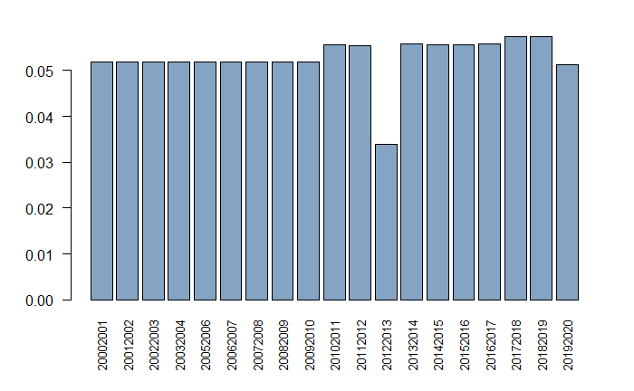

```r
barplot(prop.table(table(df$season)), las=2, cex.names=.8, col=rgb(0.2,0.4,0.6,0.6))
```

```r
tail(sort(table(df$season)))
```

```
20142015 20152016 20132014 20162017 20182019 20172018
    1319     1321     1323     1323     1360     1363
```

Z výpisu aj grafu môžeme vidieť, že najviac zápasov máme v sezónach 2017/2018 a 2018/2019. Zaujímavosťou je, že medzi sezóny s najväčším počtom odohraných zápasov nepatrí posledná odohraná sezóna, t.j. 2019/2020.

### Atribút type

**charakteristika:** atribút reprezentuje typ odohraného zápasu. Nadobúda tri základné hodnoty:

- R - regular, označuje regulárne zápasy ktoré sa hrajú počas NHL sezóny
- P - playoff, označuje zápasy vyraďovacej časti NHL, hrajú sa na konci sezóny. Tejto časti sa zúčastňujú iba najlepšie tímy.
- A - ?

```r
unique(df$type)
```

```
[1] "R" "P" "A"
```

```r
table(df$type)
```

```
    A     P     R
    5   924 22806
```

Z početností jednotlivých atribútov môžeme vidieť obrovskú prevahu zápasov regulárnej časti sezóny, čo aj zodpovedá skutočnosti…

Hodnotu ‘A’ nadobúda len 5 záznamov, v žiadnom z nich sa nejedná o zápasy tímov NHL. Hodnotu NA nemá žiaden atribút.

```r
subset(df, type=='A')
```

| season | type | goals.away | goals.home | team_id.away | HoA.away | won.away | shots.away | hits.away | pim.away | powerPlayOpportunities.away | powerPlayGoals.away | faceOffWinPercentage.away | giveaways.away | takeaways.away | blocked.away | abbreviation.away | team_id.home | HoA.home | won.home | settled_in | shots.home | hits.home | pim.home | powerPlayOpportunities.home | powerPlayGoals.home | faceOffWinPercentage.home | giveaways.home | takeaways.home | blocked.home | … |
| --- | --- | --- | --- | --- | --- | --- | --- | --- | --- | --- | --- | --- | --- | --- | --- | --- | --- | --- | --- | --- | --- | --- | --- | --- | --- | --- | --- | --- | --- | --- |
| 20192020 | A | 5 | 9 | 88 | away | FALSE | 16 | 0 | 0 | 0 | 0 | 76.2 | 0 | 2 | 1 | NA | 87 | home | TRUE | tbc | 22 | 1 | 0 | 0 | 0 | 23.8 | 1 | 4 | 0 | … |
| 20192020 | A | 10 | 5 | 90 | away | TRUE | 28 | 0 | 0 | 0 | 0 | 35.0 | 1 | 6 | 1 | NA | 89 | home | FALSE | tbc | 17 | 0 | 0 | 0 | 0 | 65.0 | 1 | 8 | 1 | … |
| 20192020 | A | 4 | 5 | 87 | away | FALSE | 11 | 0 | 0 | 0 | 0 | 37.5 | 2 | 5 | 2 | NA | 90 | home | TRUE | tbc | 20 | 0 | 0 | 0 | 0 | 62.5 | 1 | 6 | 2 | … |
| 20182019 | A | 7 | 4 | 88 | away | TRUE | 26 | 0 | 0 | 0 | 0 | 56.2 | 2 | 6 | 1 | NA | 87 | home | FALSE | tbc | 20 | 0 | 0 | 0 | 0 | 43.8 | 1 | 8 | 0 | … |
| 20182019 | A | 10 | 5 | 88 | away | TRUE | 22 | 0 | 0 | 0 | 0 | 45.0 | 3 | 5 | 1 | NA | 89 | home | FALSE | tbc | 23 | 0 | 0 | 0 | 0 | 55.0 | 4 | 4 | 2 | … |

### Atribúty goals.home a goals.away

**charakteristika:** atribút reprezentuje počet gólov z pohľadu domáceho a hosťovského tímu.

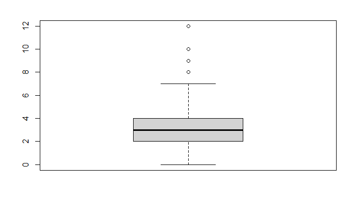

```r
boxplot(df$goals.home)
```

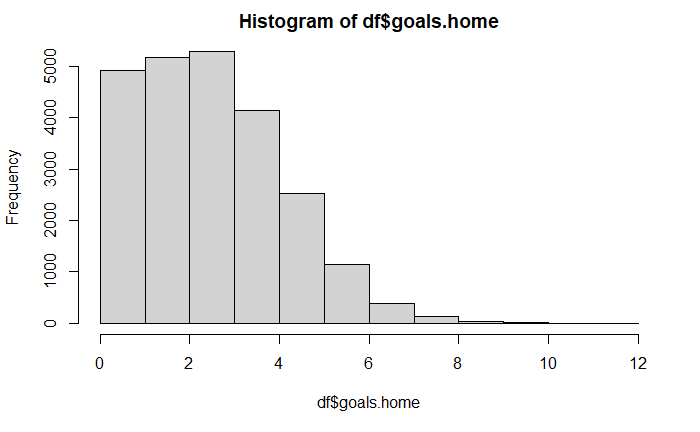

```r
hist(df$goals.home)
```

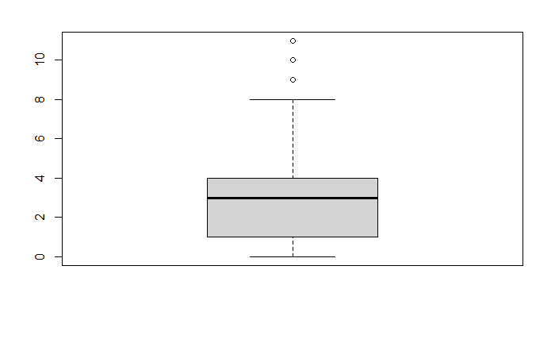

```r
boxplot(df$goals.away)
```

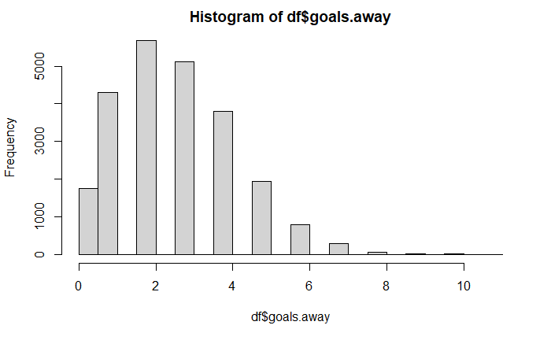

```r
hist(df$goals.away)
```

### Atribúty shots.home a shots.away

**charakteristika:** atribút reprezentuje počet striel na bránu z pohľadu domáceho a hosťovského tímu.

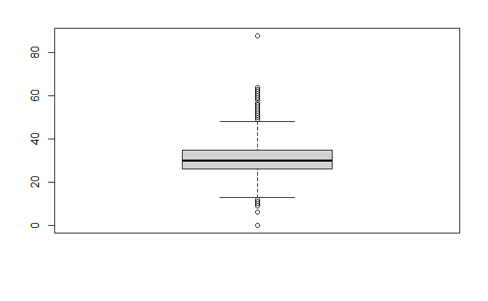

```r
boxplot(df$shots.home)
```

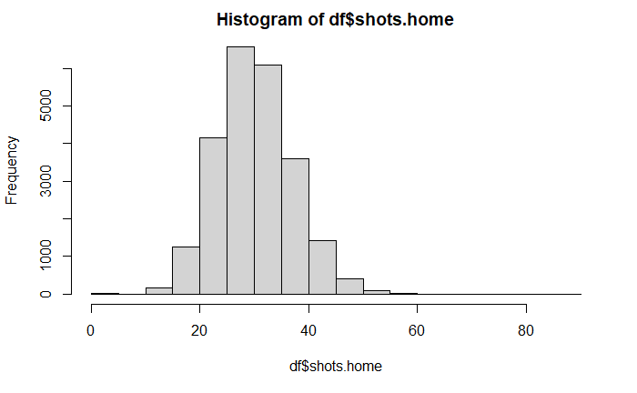

```r
hist(df$shots.home)
```

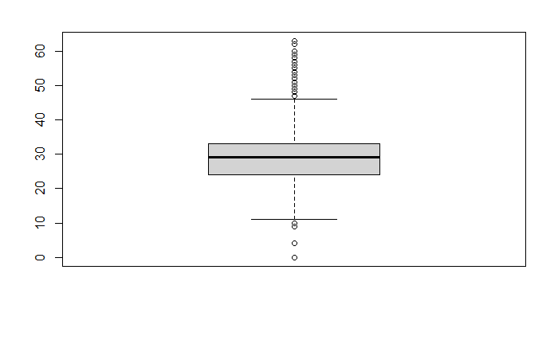

```r
boxplot(df$shots.away)
```

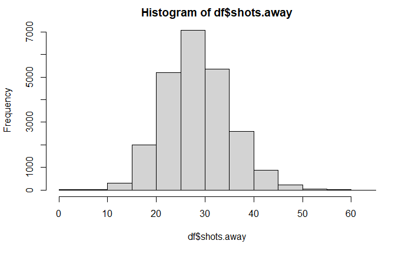

```r
hist(df$shots.away)
```

Z histogramov možno vidieť, že atribúty shots majú normálnu distribúciu.

```r
table(is.na(df$shots.home))
```

```
FALSE  TRUE
23731     4
```

```r
table(is.na(df$shots.away))
```

```
FALSE  TRUE
23731     4
```

Keď sa bližsie pozrieme na výsledok funkcie is.na(), môžeme vidieť, že oba atribúty shots (home aj away) obsahujú prázdne hodnoty v 4 záznamoch. Tie je potrebné v rámci čistenia dát odstrániť, resp. nahradiť. Vhodnou metódou môže byť napr. nahradenie priemernou hodnotou striel na bránu z ostatných zápasov tímu v sezóne.

### Atribúty won.home a won.away

**charakteristika:** jedná sa o boolean atribúty, vyjadrujú ktorý tím v zápase zvíťazil. V drtivej väčšine prípadov sú opačné, t.j TRUE FALSE alebo FALSE TRUE. Môže však nastať aj situácia v ktorej majú oba hodnotu FALSE.

Výsledok zápasu TRUE TRUE nie je možný. Preto je potrebné skontrolovať, či sa v datasete tento výsledok nenachádza (ak áno je potrebné ho opraviť). Po kontrole s vysužitím funkcie unique sme zistili, že TRUE TRUE sa v datasete nachádza 0x. FALSE FALSE sa vŠak v datasete nachádza 642x - jedná sa o remízy - tie boli v NHL zrušené, skontrolovať si to môžeme vypísaním unikátnych sezón v týchto 642 prípadoch.

```r
unique(df$won.home)
```

```
[1]  TRUE FALSE
```

```r
unique(df$won.away)
```

```
[1] FALSE  TRUE
```

```r
subset(df, won.home==TRUE & won.away==TRUE)
```

| season | type | goals.away | goals.home | team_id.away | HoA.away | won.away | shots.away | hits.away | pim.away | powerPlayOpportunities.away | powerPlayGoals.away | faceOffWinPercentage.away | giveaways.away | takeaways.away | blocked.away | abbreviation.away | team_id.home | HoA.home | won.home | settled_in | shots.home | hits.home | pim.home | powerPlayOpportunities.home | powerPlayGoals.home | faceOffWinPercentage.home | giveaways.home | takeaways.home | blocked.home | … |
| --- | --- | --- | --- | --- | --- | --- | --- | --- | --- | --- | --- | --- | --- | --- | --- | --- | --- | --- | --- | --- | --- | --- | --- | --- | --- | --- | --- | --- | --- | --- |

```r
subset(df, won.home==FALSE & won.away==FALSE)
```

| season | type | goals.away | goals.home | team_id.away | HoA.away | won.away | shots.away | hits.away | pim.away | powerPlayOpportunities.away | powerPlayGoals.away | faceOffWinPercentage.away | giveaways.away | takeaways.away | blocked.away | abbreviation.away | team_id.home | HoA.home | won.home | settled_in | shots.home | hits.home | pim.home | powerPlayOpportunities.home | powerPlayGoals.home | faceOffWinPercentage.home | giveaways.home | takeaways.home | blocked.home | … |
| --- | --- | --- | --- | --- | --- | --- | --- | --- | --- | --- | --- | --- | --- | --- | --- | --- | --- | --- | --- | --- | --- | --- | --- | --- | --- | --- | --- | --- | --- | --- |
| 20022003 | R | 1 | 1 | 29 | away | FALSE | 25 | 0 | 13 | 1 | 0 | NA | 0 | 0 | 0 | CBJ | 18 | home | FALSE | OT | 34 | 3 | 9 | 3 | 0 | NA | 0 | 0 | 0 | … |
| 20022003 | R | 1 | 1 | 14 | away | FALSE | 22 | 2 | 16 | 2 | 0 | NA | 0 | 0 | 0 | TBL | 12 | home | FALSE | OT | 28 | 7 | 8 | 6 | 1 | NA | 0 | 0 | 0 | … |
| 20022003 | R | 3 | 3 | 16 | away | FALSE | 43 | 1 | 19 | 6 | 0 | NA | 0 | 0 | 0 | CHI | 12 | home | FALSE | OT | 28 | 5 | 19 | 6 | 2 | NA | 0 | 0 | 0 | … |
| 20022003 | R | 4 | 4 | 23 | away | FALSE | 40 | 7 | 16 | 6 | 1 | NA | 0 | 0 | 0 | VAN | 29 | home | FALSE | OT | 28 | 9 | 14 | 7 | 1 | NA | 0 | 0 | 0 | … |
| 20022003 | R | 4 | 4 | 19 | away | FALSE | 33 | 24 | 28 | 5 | 1 | NA | 5 | 8 | 10 | STL | 23 | home | FALSE | OT | 20 | 25 | 24 | 2 | 1 | NA | 9 | 10 | 17 | … |
| 20022003 | R | 3 | 3 | 23 | away | FALSE | 33 | 20 | 12 | 7 | 1 | NA | 19 | 4 | 11 | VAN | 10 | home | FALSE | OT | 19 | 27 | 18 | 4 | 1 | NA | 14 | 3 | 13 | … |
| 20022003 | R | 3 | 3 | 22 | away | FALSE | 32 | 4 | 22 | 5 | 0 | NA | 0 | 0 | 0 | EDM | 23 | home | FALSE | OT | 28 | 4 | 16 | 9 | 2 | NA | 0 | 0 | 0 | … |
| 20022003 | R | 1 | 1 | 5 | away | FALSE | 28 | 9 | 18 | 5 | 0 | NA | 7 | 3 | 8 | PIT | 16 | home | FALSE | OT | 34 | 20 | 22 | 3 | 0 | NA | 4 | 1 | 9 | … |
| 20022003 | R | 2 | 2 | 14 | away | FALSE | 30 | 18 | 10 | 3 | 1 | NA | 13 | 9 | 10 | TBL | 11 | home | FALSE | OT | 35 | 17 | 8 | 4 | 0 | NA | 10 | 16 | 11 | … |
| 20022003 | R | 4 | 4 | 9 | away | FALSE | 36 | 1 | 18 | 6 | 2 | NA | 0 | 0 | 0 | OTT | 12 | home | FALSE | OT | 41 | 4 | 14 | 9 | 0 | NA | 0 | 0 | 0 | … |

[output cut: 632 more lines]

```r
verif <- subset(df, won.home==FALSE & won.away==FALSE)
```

Z výpisu môžeme vidieť, že remízy boli naposledy v sezóne 2017/2018.

```r
unique(verif$season)
```

```
[1] 20022003 20032004 20002001 20012002 20172018 20162017
```

```r
table(is.na(df$won.home))
```

```
FALSE
23735
```

```r
table(is.na(df$won.away))
```

```
FALSE
23735
```

Atribúty won.home a won.away neobsahujú žiadne prázdne hodnoty, preto nie je potrebné volenie stratégie ich nahrádzania.

### Atribúty pim.home a pim.away

**charakteristika:** atribút reprezentuje hodnotu trestných minút, ktoré boli udelené hráčom tímu počas zápasu.

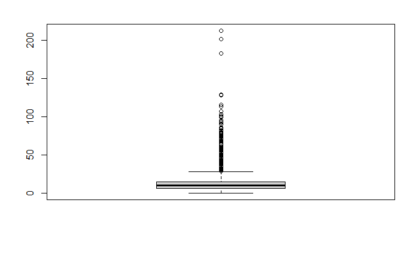

```r
boxplot(df$pim.home)
```

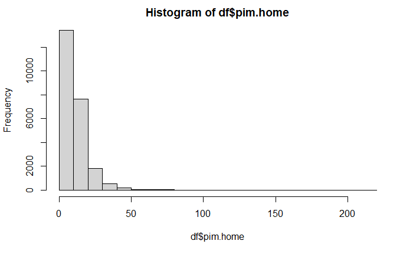

```r
hist(df$pim.home)
```

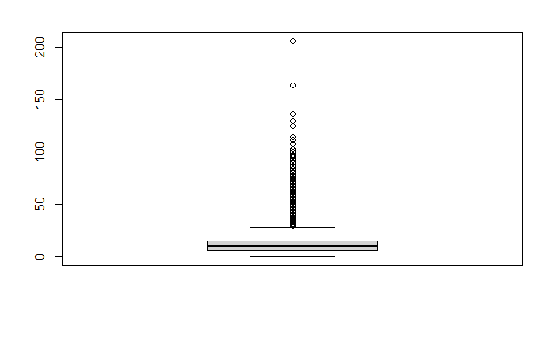

```r
boxplot(df$pim.away)
```

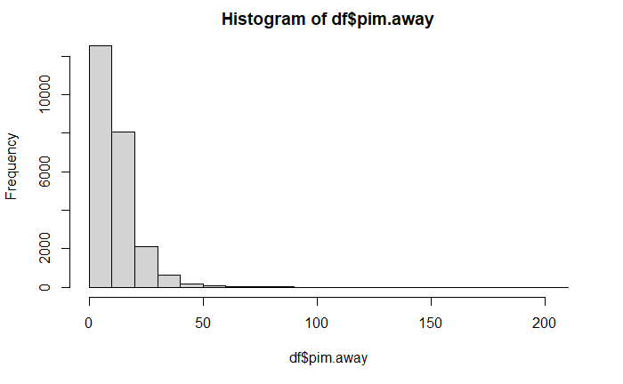

```r
hist(df$pim.away)
```

Z boxplotov môžeme vidieť, že počty trestných minút v niektorých zápasoch dostávajú veľmi vysoké hodnoty. Tie by pravdepodobne bolo vhodné znormovať s využitím kvantilov. Distribúcia hodnôt je naklonená vpravo, t.j *skewed right*.

```r
table(is.na(df$pim.home))
```

```
FALSE  TRUE
23731     4
```

```r
table(is.na(df$pim.away))
```

```
FALSE  TRUE
23731     4
```

Atribúty nadobúdajú prázdne hodnoty v 4 prípadoch, je potrebné ich nahradiť prostredníctvom vybranej stratégie. Kedže sa jedna už o druhú situáciu kedy sme narazili na 4 chýbajúce hodnoty, tieto problémové záznamy si vypíšeme.

```r
subset(df, is.na(pim.home)==TRUE)
```

| season | type | goals.away | goals.home | team_id.away | HoA.away | won.away | shots.away | hits.away | pim.away | powerPlayOpportunities.away | powerPlayGoals.away | faceOffWinPercentage.away | giveaways.away | takeaways.away | blocked.away | abbreviation.away | team_id.home | HoA.home | won.home | settled_in | shots.home | hits.home | pim.home | powerPlayOpportunities.home | powerPlayGoals.home | faceOffWinPercentage.home | giveaways.home | takeaways.home | blocked.home | … |
| --- | --- | --- | --- | --- | --- | --- | --- | --- | --- | --- | --- | --- | --- | --- | --- | --- | --- | --- | --- | --- | --- | --- | --- | --- | --- | --- | --- | --- | --- | --- |
| 20172018 | P | 0 | 0 | 28 | away | FALSE | NA | NA | NA | NA | NA | NA | NA | NA | NA | SJS | 24 | home | FALSE | tbc | NA | NA | NA | NA | NA | NA | NA | NA | NA | … |
| 20172018 | P | 0 | 0 | 52 | away | FALSE | NA | NA | NA | NA | NA | NA | NA | NA | NA | WPG | 54 | home | FALSE | tbc | NA | NA | NA | NA | NA | NA | NA | NA | NA | … |
| 20172018 | P | 0 | 0 | 54 | away | FALSE | NA | NA | NA | NA | NA | NA | NA | NA | NA | VGK | 52 | home | FALSE | tbc | NA | NA | NA | NA | NA | NA | NA | NA | NA | … |
| 20162017 | P | 0 | 0 | 3 | away | FALSE | NA | NA | NA | NA | NA | NA | NA | NA | NA | NYR | 9 | home | FALSE | tbc | NA | NA | NA | NA | NA | NA | NA | NA | NA | … |

Môžeme vidieť že sa jedná o zápasy ktoré pre nás nemajú žiadnu pridanú hodnotu, keďže všetky relevantné atribúty dosahujú hodnotu NA. Je preto vhodné tieto štyri atribúty z tabuľky odstrániť a opätovne skontrolovať predošlé chýbajúce hodnoty.

```r
#df <- subset(df, is.na(pim.home)==FALSE)
#table(is.na(df$pim.home))
#table(is.na(df$pim.away))
#Po úprave datasetu už sú všetky hodnoty atribútov pim.home a pim.away neprázdne.
```

### Atribúty faceOffWinPercentage.home a faceOffWinPercentage.away

**charakteristika:** atribút reprezentuje úspešnosť vyhraných vhadzovaní v percentách.

```r
table(is.na(df$faceOffWinPercentage.home))
```

```
FALSE  TRUE
12661 11074
```

```r
unique(subset(df, is.na(faceOffWinPercentage.home)==TRUE)$season)
```

```
 [1] 20092010 20082009 20072008 20062007 20022003 20032004 20052006 20002001 20012002 20172018 20162017
```

```r
table(is.na(df$faceOffWinPercentage.away))
```

```
FALSE  TRUE
12661 11074
```

```r
unique(subset(df, is.na(faceOffWinPercentage.away)==TRUE)$season)
```

```
 [1] 20092010 20082009 20072008 20062007 20022003 20032004 20052006 20002001 20012002 20172018 20162017
```

```r
(100/23735)*11074
```

```
[1] 46.65684
```

Vidíme, že atribút obsahuje takmer 50% chýbajúcich hodnôt. Keďže chýbajúce hodnoty atribútu sú aj v novších sezónach, s ktorými chceme pracovať, bude potrebné bližšie preskúmať záznamy obsahujúce tento chýbajúci atribút.

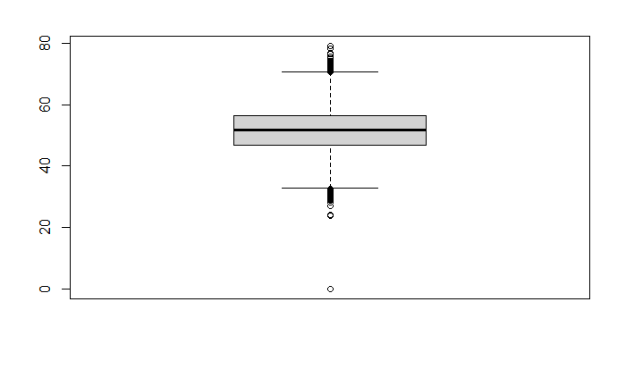

```r
boxplot(df$faceOffWinPercentage.home)
```

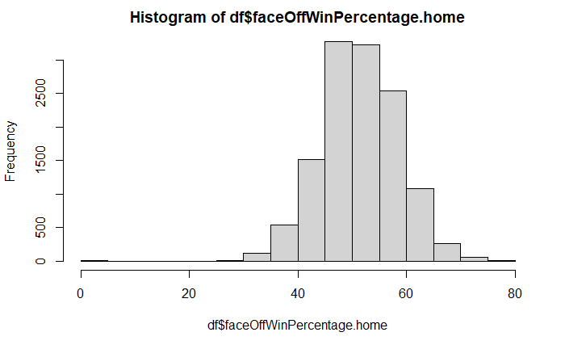

```r
hist(df$faceOffWinPercentage.home)
```

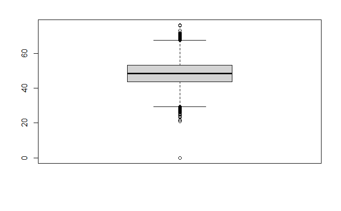

```r
boxplot(df$faceOffWinPercentage.away)
```

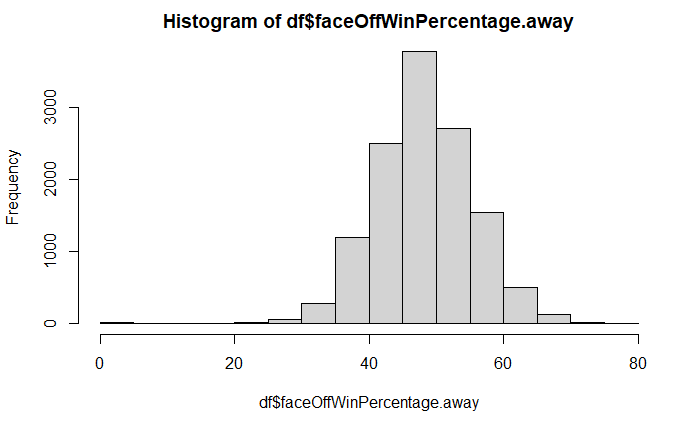

```r
hist(df$faceOffWinPercentage.away)
```

Nakoľko hodnoty NA atribútu faceOffWinPercentage sú aj v sezónach, s ktorými chceme pracovať (2016-2018), potrebujeme si tieto záznamy vypísať a na základe výpisu môžeme navrhnúť spôsob, akým tieto hodnoty nahradíme/odstránime.

```r
subset(df, (season==20172018 | season==20162017) & (is.na(faceOffWinPercentage.away)==TRUE | is.na(faceOffWinPercentage.home)==TRUE))
```

| season | type | goals.away | goals.home | team_id.away | HoA.away | won.away | shots.away | hits.away | pim.away | powerPlayOpportunities.away | powerPlayGoals.away | faceOffWinPercentage.away | giveaways.away | takeaways.away | blocked.away | abbreviation.away | team_id.home | HoA.home | won.home | settled_in | shots.home | hits.home | pim.home | powerPlayOpportunities.home | powerPlayGoals.home | faceOffWinPercentage.home | giveaways.home | takeaways.home | blocked.home | … |
| --- | --- | --- | --- | --- | --- | --- | --- | --- | --- | --- | --- | --- | --- | --- | --- | --- | --- | --- | --- | --- | --- | --- | --- | --- | --- | --- | --- | --- | --- | --- |
| 20172018 | P | 0 | 0 | 28 | away | FALSE | NA | NA | NA | NA | NA | NA | NA | NA | NA | SJS | 24 | home | FALSE | tbc | NA | NA | NA | NA | NA | NA | NA | NA | NA | … |
| 20172018 | P | 0 | 0 | 52 | away | FALSE | NA | NA | NA | NA | NA | NA | NA | NA | NA | WPG | 54 | home | FALSE | tbc | NA | NA | NA | NA | NA | NA | NA | NA | NA | … |
| 20172018 | P | 0 | 0 | 54 | away | FALSE | NA | NA | NA | NA | NA | NA | NA | NA | NA | VGK | 52 | home | FALSE | tbc | NA | NA | NA | NA | NA | NA | NA | NA | NA | … |
| 20162017 | P | 0 | 0 | 3 | away | FALSE | NA | NA | NA | NA | NA | NA | NA | NA | NA | NYR | 9 | home | FALSE | tbc | NA | NA | NA | NA | NA | NA | NA | NA | NA | … |

Tiež je potrebné si všimnúť, že atribút settled_in obsahuje hodnotu tbc. Tento atribút potrebujeme analyzovať a zistiť, aké hodnoty nadobúda, aby sme mohli upraviť záznamy s touto hodnotou.

### Atribút settled_in

**charakteristika:** atribút reprezentuje, akým spôsobom bol zápas ukončený (napríklad v riadnom hracom čase / v predĺžení).

```r
unique(df$settled_in)
```

```
[1] "REG" "OT"  "tbc"
```

Popis hodnôt: * REG - zápas ukončený v riadnom hracom čase * OT - zápas ukončený v predĺžení * tbc - zápas ukončený neregulárnym spôsobom (zrušený/odložený)

Zápasy s hodnotou tbc v atribúte settled_in nie sú vhodné pre štatistickú analýzu, ktorú budeme vykonávať. Vypíšeme si počet zápasov, ktoré neboli ukončené regulárne.

```r
table(df$settled_in)
```

```
   OT   REG   tbc
 5563 18153    19
```

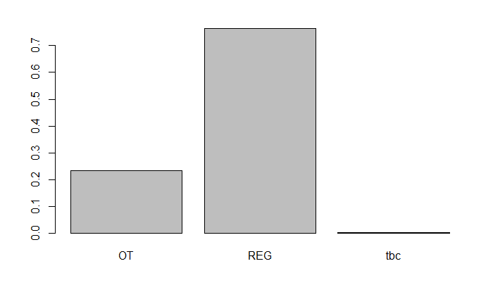

```r
barplot(prop.table(table(df$settled_in)))
```

Vidíme, že počet takých zápasov je 19. Napriek tomu, že je to zanedbateľné číslo, je potrebné tieto záznamy v ďalšej fáze projektu odstrániť. Tiež si môžeme všimnúť, že približne 70+% zápasov je ukončených v regulárnom hracom čase, zatiaľ čo počet zápasov ukončených v predĺžení je približne 20+%.

### Odstránenie NA hodnôt

Ako bolo spomenúté vyššie, zápasy s hodnotou tbc v atribúte settled_in obsahujú nežiadúce (NA) hodnoty. Tieto záznamy odstránime.

```r
dim(df)
```

```
[1] 23735    31
```

```r
df <- subset(df, df$settled_in!='tbc')
dim(df)
```

```
[1] 23716    31
```

```r
sapply(df, function(x) sum(is.na(x)))
```

```
                     season                        type                  goals.away                  goals.home
                          0                           0                           0                           0
               team_id.away                    HoA.away                    won.away                  shots.away
                          0                           0                           0                           0
                  hits.away                    pim.away powerPlayOpportunities.away         powerPlayGoals.away
                       2460                           0                           0                           0
  faceOffWinPercentage.away              giveaways.away              takeaways.away                blocked.away
                      11070                        2460                        2460                        2460
          abbreviation.away                team_id.home                    HoA.home                    won.home
                          0                           0                           0                           0
                 settled_in                  shots.home                   hits.home                    pim.home
                          0                           0                        2460                           0
powerPlayOpportunities.home         powerPlayGoals.home   faceOffWinPercentage.home              giveaways.home
                          0                           0                       11070                        2460
             takeaways.home                blocked.home           abbreviation.home
                       2460                        2460                           0
```

### Párová analýza dát

V tejto časti chceme identifikovať možné vzťahy medzi jednotlivými atribútmi prostredníctvom výpočtu korelácií, respektíve korelačnej matice. Nakoľko niektoré atribúty obsahujú nenumerické hodnoty, pre prvotnú identifikáciu možných vzťahov medzi atribútmi použijeme iba atribúty s numerickými hodnotami.

```r
df$won.home[df$won.home == "TRUE"] <- "1"
df$won.home[df$won.home == "FALSE"] <- "0"
df$won.away[df$won.away == "TRUE"] <- "1"
df$won.away[df$won.away == "FALSE"] <- "0"
class(df$won.home) = "numeric"
class(df$won.away) = "numeric"
unique(df$won.home)
```

```
[1] 1 0
```

```r
unique(df$won.away)
```

```
[1] 0 1
```

```r
df_numeric <- subset(df, select=-c(type, HoA.away, abbreviation.away, HoA.home, settled_in, abbreviation.home))
sapply(df, is.numeric) # won.away, won.home,
```

```
                     season                        type                  goals.away                  goals.home
                       TRUE                       FALSE                        TRUE                        TRUE
               team_id.away                    HoA.away                    won.away                  shots.away
                       TRUE                       FALSE                        TRUE                        TRUE
                  hits.away                    pim.away powerPlayOpportunities.away         powerPlayGoals.away
                       TRUE                        TRUE                        TRUE                        TRUE
  faceOffWinPercentage.away              giveaways.away              takeaways.away                blocked.away
                       TRUE                        TRUE                        TRUE                        TRUE
          abbreviation.away                team_id.home                    HoA.home                    won.home
                      FALSE                        TRUE                       FALSE                        TRUE
                 settled_in                  shots.home                   hits.home                    pim.home
                      FALSE                        TRUE                        TRUE                        TRUE
powerPlayOpportunities.home         powerPlayGoals.home   faceOffWinPercentage.home              giveaways.home
                       TRUE                        TRUE                        TRUE                        TRUE
             takeaways.home                blocked.home           abbreviation.home
                       TRUE                        TRUE                       FALSE
```

```r
# cor(df_numeric, use="complete.obs")
```

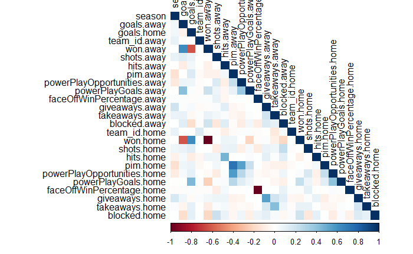

```r
corrplot(cor(df_numeric, use="complete.obs"), type="lower", method="color", tl.col="black")
```

Môžeme vidieť že najväčšie korelácie sú medzi dvojicami atribútov:

- powerPlayGoals.away - goals.away

```r
cor(df$powerPlayGoals.away, df$goals.away)
```

```
[1] 0.4534494
```

- powerPlayGoals.home - goals.home

```r
cor(df$powerPlayGoals.home, df$goals.home)
```

```
[1] 0.468251
```

- hits.home - hits.away

```r
cor(df$hits.home, df$hits.away, use="complete.obs")
```

```
[1] 0.6174939
```

- pim.home - pim.away

```r
cor(df$pim.home, df$pim.away)
```

```
[1] 0.7470763
```

- powerPlayOpportunities.home - pim.away

```r
cor(df$powerPlayOpportunities.home, df$pim.away)
```

```
[1] 0.5856751
```

- pim.home - powerPlayOpportunities.away

```r
cor(df$pim.home, df$powerPlayOpportunities.away)
```

```
[1] 0.5692446
```

- faceOffWinPercentage.home - faceOffWinPercentage.away

```r
cor(df$faceOffWinPercentage.home, df$faceOffWinPercentage.away, use="complete.obs")
```

```
[1] -1
```

- giveaways.home - giveaways.away

```r
cor(df$giveaways.home, df$giveaways.away, use="complete.obs")
```

```
[1] 0.6423127
```

- takeaways.home - takeaways.away

```r
cor(df$takeaways.home, df$takeaways.away, use="complete.obs")
```

```
[1] 0.537522
```

### Hypotézy

1. Čím viac trestných minút (pim) má daný tím, tým je väčšia pravdepodobnosť, že zápas prehrá.
2. Čím je väčší počet striel na bránu (shots), tým viac gólov padne v zápase (goals).
3. Čím viac striel tím zblokuje (blocked), tým menej gólov nastriela oponent (goals).
4. Čím viac kontaktných súbojov (hits) je v zápase, tým viac je v zápase trestných minút (pim).

## Analýzka, veci

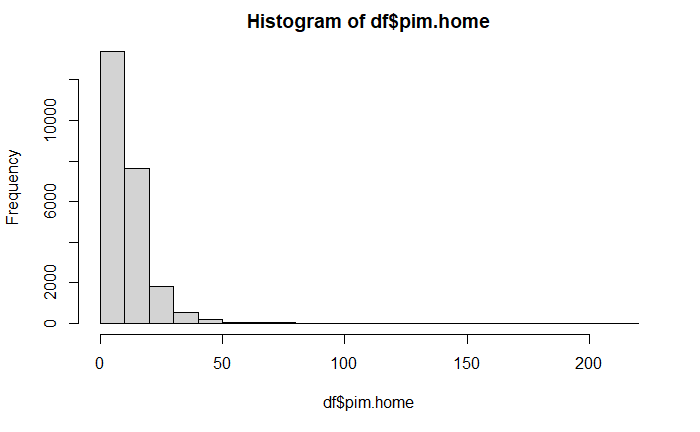

```r
hist(df$pim.home)
```

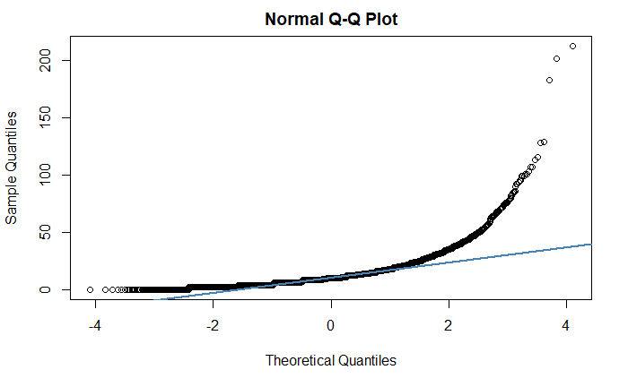

```r
qqnorm(df$pim.home)
qqline(df$pim.home, col = "steelblue", lwd = 2)
```

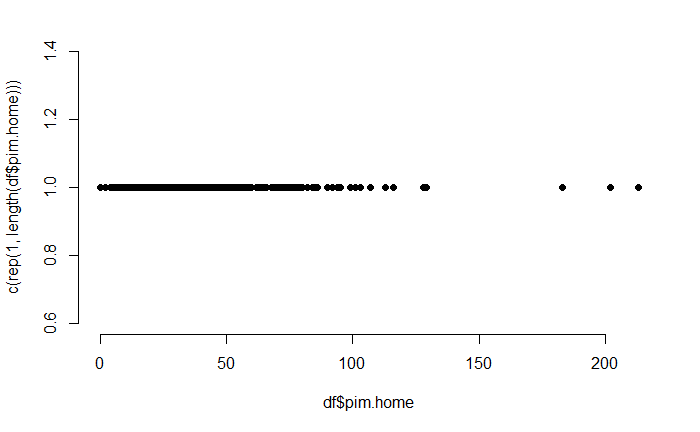

```r
plot(df$pim.home, c(rep(1,length(df$pim.home))), pch = 19, frame = FALSE)
```

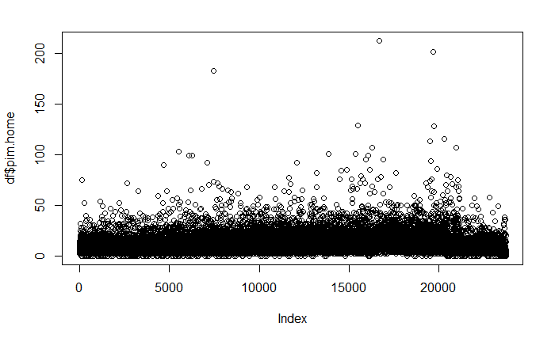

```r
#plot(1:length(df$pim.home), df$pim.home)
plot(df$pim.home)
```

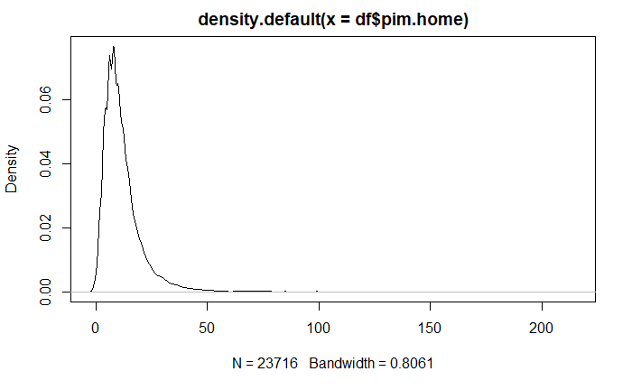

```r
plot(density(df$pim.home))
```

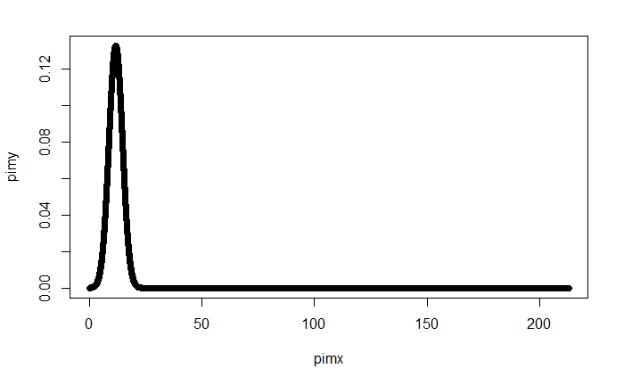

```r
pimx<-seq(min(df$pim.home), max(df$pim.home), length=length(df$pim.home))
pimy<-dnorm(pimx, mean=mean(df$pim.home), sd=3)
plot(pimx, pimy)
```

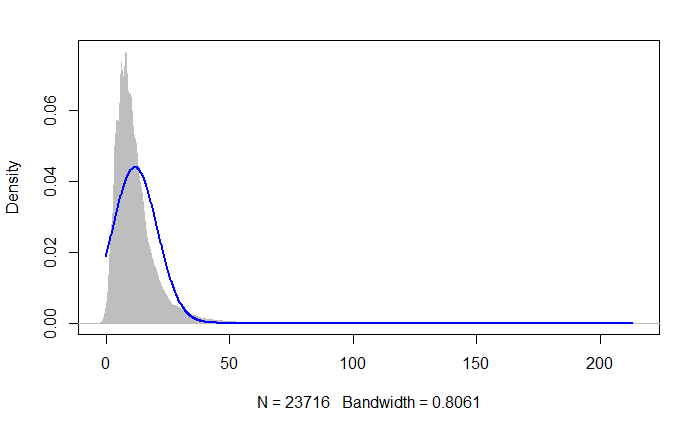

```r
plotNormalDensity(df$pim.home)
```

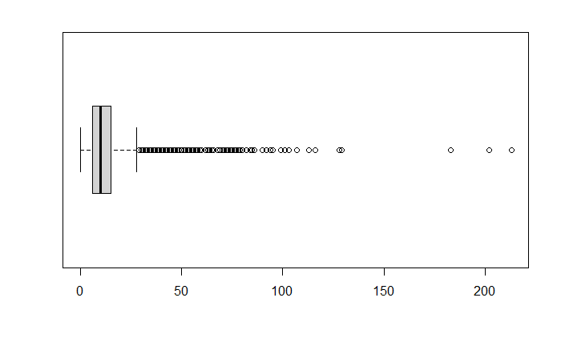

```r
boxplot(df$pim.home, horizontal = TRUE)
```